# Bayesian Palaeoclimate Reconstruction from Pollen data with Bclim

Andrew Parnell, Thinh Doan, and James Sweeney

2016-12-22

## Introduction

This vignette contains the code and associated descriptions to re-create the plots given in the Parnell et al submitted paper *Joint palaeoclimate reconstruction from pollen data via forward models and climate histories*. It is not meant to be a completed vignette, and it is not a complete instruction manual yet. If you spot bugs or mistakes please post to the [GitHub repository](http://github.com/andrewcparnell/Bclim). Some of the code below takes a long time to run, so you can shortcut the steps by downloading the resulting files from [my website](https://maths.ucd.ie/parnell/). The places where this is relevant are all given in the code below.

## Installation

The stable version can be downloaded at the R command prompt with:

```r
install.packages('Bclim')
```

The latest version, which usually contains extra bug fixes, or experimental functions which might not work well yet, is available via:

```r
devtools::install_github('andrewcparnell/Bclim')
```

Note that for the above you need to have installed the `devtools` package.

If the installation has worked correctly no error should be returned upon typing:

```r
library(Bclim)
```

## Roya

To create the plots for Roya we first need to create a chronology using the `Bchron` package before we can run `Bclim` on it.

We run the `Bchron` step with:

```r
library(Bchron)

# load in dates
Roya_dates = read.table(system.file("extdata",
                                    "Roya.dat",
                                    package = "Bclim"),
                        header=TRUE)

# Load in the pollen depths
Roya_depths = read.table(system.file("extdata",
                                     "Roya_pollen_depths.txt",
                                     package = "Bclim"))

# Run Bchron
Roya_chron = with(Roya_dates,
                  Bchronology(ages=Age,
                              ageSds=sd,
                              positions=Depth,
                              positionThickness=Thickness,
                              id=id,
                              predictPositions=Roya_depths$V1,
                              thin = 4))
```

We can check convergence with:

```r
# Check convergence
summary(Roya_chron,type='convergence') # Good
```

```
## Convergence check (watch for too many small p-values):
##           p-value
## Outlier 2 0.00095
## Outlier 4 0.00130
## RateMean  0.00511
## Outlier 6 0.00661
## Roya_6    0.02845
## Roya_2    0.05214
## RateVar   0.05517
## Outlier 1 0.18462
## Roya_5    0.33650
## Roya_4    0.34755
## Roya_1    0.39265
## Outlier 3 0.40468
## Roya_3    0.44725
## Outlier 5 0.49855
```

And plot the chronology with

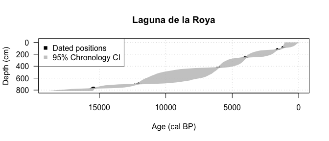

```r
# Plot
plot(Roya_chron,xlab='Age (cal BP)',ylab='Depth (cm)',main='Laguna de la Roya',las=1)
```

We can now run Bclim with:

```r
# Load in the pollen data
Roya_pollen = read.table(system.file("extdata",
                                    "Roya_pollen.txt",
                                    package = "Bclim"),
                        header=TRUE)

# Extract the chronologies - Bclim requires them in thousands of years
Roya_chronologies = Roya_chron$thetaPredict/1000

# Run the single slice climate clouds
Roya_slices = slice_clouds(Roya_pollen)

# Run the climate histories function -
Roya_histories = climate_histories(slice_clouds = Roya_slices,
                              chronology = Roya_chronologies,
                              time_grid = seq(0,16,by=0.1))
```

We can plot a single slice of the climate clouds:

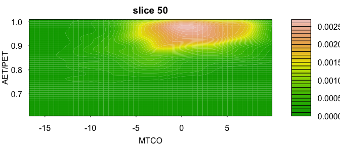

```r
# Plot a single slice cloud if required - plot slice 50
par(mar=c(3,3,2,1), mgp=c(2,.7,0), tck=-.01,las=1)
plot(Roya_histories$slice_clouds,slice=50, dims=2:3, main='slice 50',xlab='MTCO',ylab='AET/PET',col=terrain.colors(30))
```

Plot the climate histories:

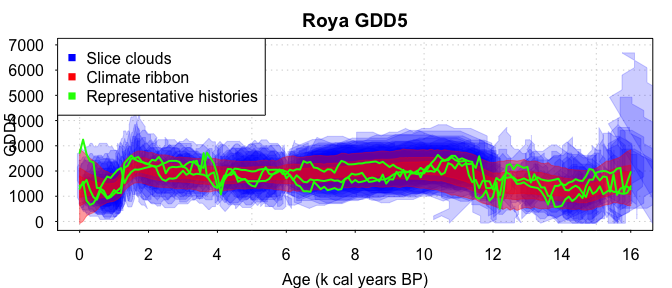

```r
# Plot the climate histories
par(mar=c(3,3,2,1), mgp=c(2,.7,0), tck=-.01,las=1)
plot(Roya_histories, most_representative = 3, chron=Roya_chronologies,xlab='Age (k cal years BP)',ylab='GDD5',main='Roya GDD5')
legend('topleft',legend=c('Slice clouds','Climate ribbon','Representative histories'),pch=15,col=c('blue','red','green'))
```

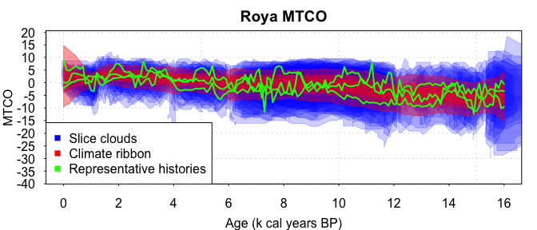

```r
plot(Roya_histories,dim=2,most_representative = 3,chron=Roya_chronologies,xlab='Age (k cal years BP)',ylab='MTCO',main='Roya MTCO')
legend('bottomleft',legend=c('Slice clouds','Climate ribbon','Representative histories'),pch=15,col=c('blue','red','green'))
```

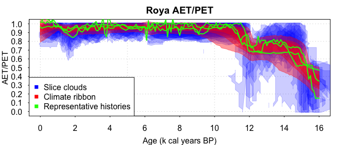

```r
par(mar=c(3,3,2,1), mgp=c(2,.7,0), tck=-.01,las=1)
plot(Roya_histories,dim=3,most_representative = 3, chron=Roya_chronologies,xlab='Age (k cal years BP)',ylab='AET/PET',main='Roya AET/PET')
legend('bottomleft',legend=c('Slice clouds','Climate ribbon','Representative histories'),pch=15,col=c('blue','red','green'))
```

We can summarise the histories with e.g. (results not shown)

```r
# Summarise the histories if required
summary(Roya_histories,dim=3)
```

And finally create the plots of the first differences:

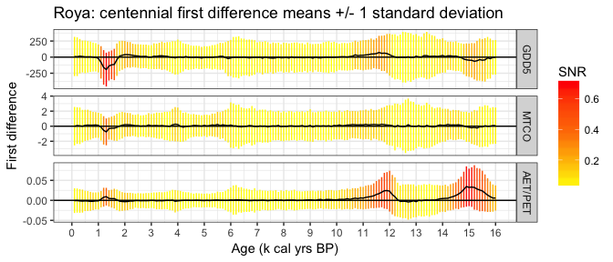

```r
### Create the plot of first differences
# This might one day become a function in Bclim

# Somewhere to store the differences
diffs = vector('list',length=3)
clim_names = c('GDD5','MTCO','AET/PET')

# Loop through each climate dimension
for(i in 1:3) {
  diffs[[i]] = -apply(Roya_histories$histories[,,i],1,'diff')
}
diff_means = lapply(diffs,'rowMeans')
diff_sds = lapply(diffs,function(x) apply(x,1,'sd'))
diff_snr = lapply(mapply("/",diff_means,diff_sds,SIMPLIFY = FALSE),'abs')
df = data.frame(tg=rep(Roya_histories$time_grid[-1],3),
                diff_means=unlist(diff_means),
                diff_sds=unlist(diff_sds),
                SNR=unlist(diff_snr),
                clim_var=rep(clim_names,
                             each=length(Roya_histories$time_grid)-1))
df$clim_var = factor(df$clim_var,levels=clim_names,ordered=TRUE)

# Create the plot using ggplot2
library(ggplot2)
limits = aes(ymax = diff_means + diff_sds, ymin= diff_means - diff_sds)
p = ggplot(df,aes(x=tg,y=diff_means,colour=SNR)) +
  geom_linerange(limits) +
  geom_line(colour='black') +
  facet_grid(clim_var ~ .,scales='free_y')+ xlab('Age (k cal yrs BP)') +
  ylab('First difference') +
  ggtitle('Roya: centennial first difference means +/- 1 standard deviation') +
  scale_x_continuous(breaks=seq(0,16,by=1))+theme_bw() +
  geom_hline(aes(yintercept=0)) +
  scale_colour_gradientn(colours=rev(heat.colors(3)))
print(p)
```